# Introduction

An online survey was designed to solicit input from State DOTs to identify potential revisions to the HCM LOS methodology to help these agencies better evaluate the impact of traffic, roadway, and control characteristics on bicyclist LOS and to collect the characteristics that can classify rural cyclists.

## Survey structure

- Welcome page
- First page: respondent employment data and use of bicycle methods
- Second page: quality of service for rural cyclists
- Third page: definition of rural cyclists
- Closing

The welcome page had the introductory message to the respondent, which included the purpose of the survey, the research project, the research team, and their contact information. We also indicated that the expected time to complete the survey was 15 minutes.

In the first page of the questionnaire, respondents provided information related to their employment, such as the type of agency/company they are employed by, their field of work, and workplace location. Respondents also indicated which bicycle operations quality assessment methodologies they apply (if any), why they use them and for which types of study.

The second page of the questionnaire had a set of questions designed to evaluate the influence of different factors on the quality of service of cyclists in rural areas. Responses for two facility types were collected: shared lanes and bicycle lanes. FHWA definitions of shared lane and bicycle lane were included.

Based on the literature review, we defined 32 elements that could be relevant to estimate the quality of service of rural cyclists. Specifically, we asked *how sensitive are rural cyclist perceptions of quality of service to the following elements?*. The response scale is between *1 - No effect and 5 - Very sensitive*. All items were classified into five main categories:

- Design elements: speed limit, grade, horizontal curvature, automobile lane width, pavement condition, sight distance, driveway density, raised profile pavement markings, on street parking (section passing through small town)
- Traffic characteristics: directional automobile volume, opposing automobile volume, automobile average speed, speed differential between bicycles and automobiles, bicycle average speed, bicycle volume, lateral clearance between bicycles and automobiles, geometric delay
- Traffic control elements: signalized intersection, stop-controlled intersection, roundabout
- Adjacent land use: federal/state parks and forests, agricultural zones, industrial and military areas, commercial areas, residential areas
- Environmental conditions: rainfall, temperature, wind, snow, lighting condition, fog

Afterwards, respondents were asked to rank eight groups of variables based on their relative importance to assess the quality of service for rural cyclist. The groups of variables were:

- Design elements
- Bicycle traffic characteristics
- Automobile traffic characteristics
- Traffic control elements
- Land use
- Environmental conditions
- Subjective perception
- Safety conditions

A question on data availability was included to address possible differences across states and agencies. Specifically, respondents were asked *to what extent do you make use of these data sources to quantify/characterize the previous variables?*. The response scale is between *1 - No use and 5 - Very large extent*. Data sources included GIS data, manual traffic counts, or installation of cameras and sensors. We also included an open text box to describe their data availability, cost and/or effort issues regarding bicycle infrastructure design, and/or bicycle operational analyses.

The third page of the questionnaire is related to the possible definition of bicycle design user(s). The respondents should indicate their level of agreement with: *The following characteristics should be used to define the bicycle design user(s) for rural highways*. A 5-level scale is used: *Strongly disagree to Strongly agree*. Characteristics included trip purpose, bicycle trip frequency, cycling experience, riding group size, and rider age, among others. The attributes included most of those previously used for cyclist classification, and added a couple of variables that were important to determine bicyclist speeds, such as physical characteristics of the cyclist. Comments and/or unmentioned variables were collected in an open text question.

The closing page had questions about the cycling experience of the respondent and included an open question. Responses were stored anonymously unless the respondent chose to provide identifying information.

## Survey pretesting and distribution

A pretest was conducted with the research team members and panel members to refine overall understanding, time management and variables included. Afterwards, it was submitted to the University of Florida Institutional Review Board (UF-IRB), which oversees research studies involving human subjects.

Originally, the survey was intended for State DOTs. However, it was opened to other individuals who have experience in designing bicycle facilities and/or evaluating bicycling operational conditions. The survey was approved by UF-IRB in early December and distributed through the following channels:

- State DOT bicycle and pedestrian coordinators - December 7th, 2021; reminder sent January 26th, 2022.
- Members and friends of the TRB Committee on Highway Capacity and Quality of Service (ACP40) - December 6th, 2021.
- Members and friends of the TRB Committee on Bicycle Transportation (ACH20) - December 22nd, 2021.
- Members and friends of the TRB Committee on Performance Effects of Geometric Design (AKD10) - December 14th, 2021.

In this QPR, we present the final results of the survey.

# Descriptive analysis of the sample

## Sample size

A total of 150 persons entered the survey. 58 and 33 persons left the survey in the welcome and first page, respectively. The final number of completed responses is 55.

Number of responses by the last page of the survey

| Last page | Responses |
| --- | --- |
| 0 | 58 |
| 1 | 33 |
| 2 | 3 |
| 3 | 1 |
| 4 | 55 |

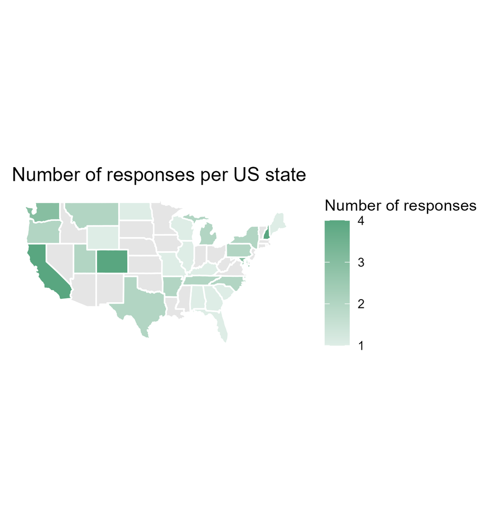

Responses per US state

## Agency, department and position

The respondents are primarily employed by state or local government (38 respondents) and consulting groups (11 respondents). They work mainly at the planning department and are engineers or planners.

By which type of agency/company are you primarily employed?

| Agency | Responses | Percentage |
| --- | --- | --- |
| State/Local Government | 38 | 41.30 |
| Consulting Group | 11 | 11.96 |
| Research Institute/University | 5 | 5.43 |
| Other | 1 | 1.09 |

In which department do you work?

| Department | Responses | Percentage |
| --- | --- | --- |
| Planning | 24 | 26.09 |
| Other | 16 | 17.39 |
| Operations | 13 | 14.13 |
| Prefer not to answer | 2 | 2.17 |

What is your position?

| Position | Responses | Percentage |
| --- | --- | --- |
| Engineer | 28 | 30.43 |
| Planner | 14 | 15.22 |
| Other | 7 | 7.61 |
| Researcher | 4 | 4.35 |
| Prefer not to answer | 2 | 2.17 |

For which type of agencies do you perform work? You can choose several agencies.

| Agency for | Responses | Percentage |
| --- | --- | --- |
| State Department of Transportation (DOT) | 46 | 83.64 |
| Municipality | 17 | 30.91 |
| County | 11 | 20.00 |
| Metropolitan Planning Organization (MPO) | 9 | 16.36 |
| Other | 7 | 12.28 |
| Federal Highway Administration (FHWA) | 6 | 10.91 |
| Private agency | 3 | 5.45 |

## Cycling experience

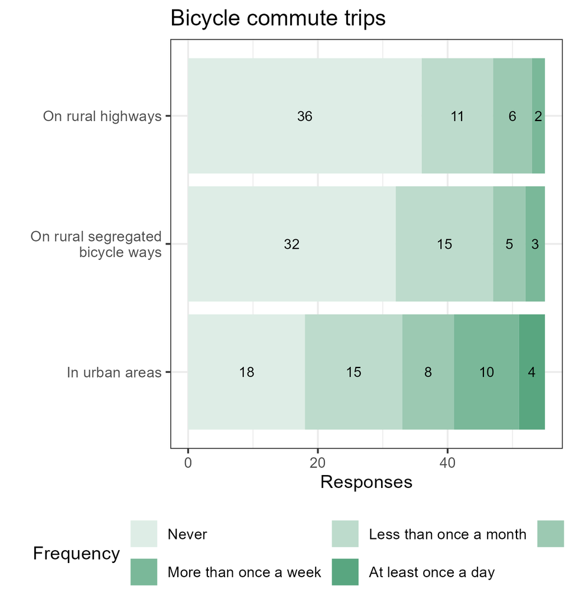

Commute cycling experience

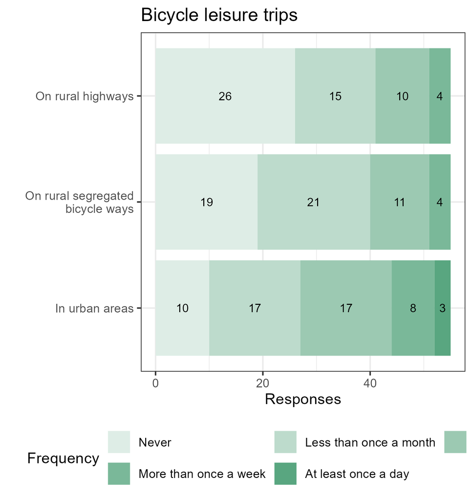

Leisure cycling experience

Respondents were classified based on their cycling experience, as follows:

- Frequent rural cyclist: cycles for commute and/or leisure on rural highways at least once per week.
- Frequent cyclist: cycles for commute and/or leisure in urban areas and/or rural segregated bicycle ways at least once per week.
- Occasional cyclist: cycles for commute and/or leisure in urban areas and/or rural segregated bicycle ways less than once a month.
- No cyclist: never cycles for commute and/or leisure in any area.

The majority of respondents are frequent cyclists, either on rural highways (16 responses) or urban areas (20 responses). 14 individuals are occasional cyclists and only 5 did not cycle.

Cycling experience of respondents

| cycling.experience | cnt | freq |
| --- | --- | --- |
| No_cyclist | 5 | 9.09 |
| frequent | 20 | 36.36 |
| ocassional | 14 | 25.45 |
| rural_experience | 16 | 29.09 |

## State DOT responses

Cycling experience of respondents

[output not shown]

Specifically, we received responses from 30 different state DOTs, including Hawaii and the District of Columbia.

# Current use of bicycle methodologies

## Methods applied

Which of the following methods do you apply? Check all that apply

| Methodology | Responses | Percentage |
| --- | --- | --- |
| Bicycle level of traffic stress | 23 | 41.82 |
| None | 21 | 38.18 |
| HCM bicycle level of service | 16 | 29.09 |
| Other | 7 | 12.28 |
| Rural bicycle compatibility index | 1 | 1.82 |

Some respondents indicate that other methodologies are applied, such as multimodal analysis tools outlined in Oregon DOT Analysis Procedure Manual, Caltrans Highway Design Manual or ATACP safety and usability guidelines for active transportation users.

Other methodologies applied

| State | Method |
| --- | --- |
| Tennessee | Local guidelines |
| California | NACTO AAA |
| Wisconsin | We have a rural highway bicycle conditions methodology which is similar to FHWA Rural Bicycle Compatibility Index. |
| Texas | when applicable use FHWA SUP LOS Calculator |
| Oregon | We use a modified simplified version of the HCM BLOS for segments and our own LOS intersection index method |
| Texas | ATACP has developed safety and usability guidelines for active transportation users, from a field/user perspective https://www.wyld.net/atacp/usability-guidelines-atacp/ |

## Reasons to use applied methods

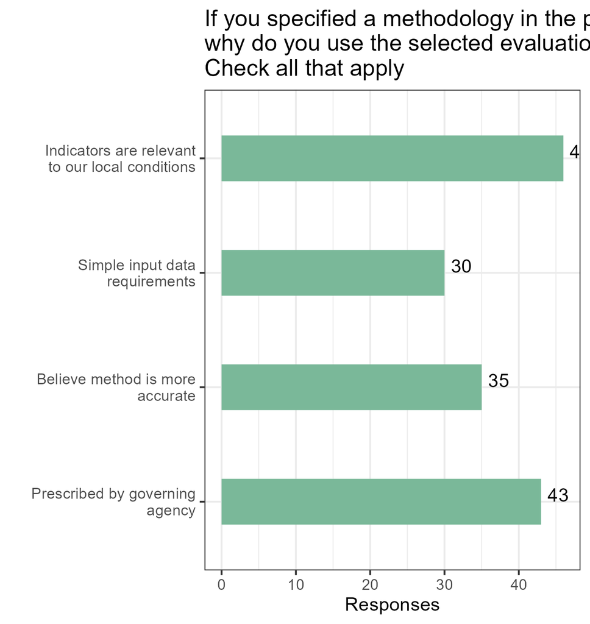

Reasons to use methods

We analyzed if there are differences in the motivations to select a specific evaluation tool. The most used method, bicycle level of traffic stress, is selected due to its simple input data and/or being prescribed by the governing agency. In the case of the HCM, the most reported reason is that the indicators are relevant to local conditions and the believe that the method is more accurate, and with the least percentage, simple input data requirements.

## Uses

For which analyses does your agency use bicycle indicators in rural highways? Select all that apply.

| Use | Responses | Percentage |
| --- | --- | --- |
| Project development | 22 | 40.00 |
| Regional transportation planning | 19 | 34.55 |
| System connectivity | 15 | 27.27 |
| Screening | 8 | 14.55 |
| Development review | 8 | 14.55 |
| Operations | 6 | 10.91 |
| Other | 1 | 1.82 |

## Concerns

In a following subsection, we included one question regarding which concerns do the respondents have regarding bicycle indicators. Not surprisingly, data availability is the highest concern, followed by insufficient staff to estimate the indicators and expensive input data. Other concerns include not being relevant to local conditions or not being capable to assess local needs.

What are your main concerns regarding bicycle indicators? Check all that apply

| Concerns | Responses | Percentage |
| --- | --- | --- |
| We do not have access to all the input data | 25 | 45.45 |
| It is challenging to have sufficient staff to estimate them | 18 | 32.73 |
| The input data are too expensive to collect | 16 | 29.09 |
| The indicators are not relevant to our local condition | 12 | 21.82 |
| Other | 11 | 20.00 |
| The indicators are not capable to assess our needs | 9 | 16.36 |
| None | 5 | 9.09 |
| The methodology is too complex | 4 | 7.27 |

What are your main concerns regarding bicycle indicators? Check all that apply

[output not shown]

## Data sources

The research team anticipated that data availability could be an important concern to apply bicycle methodologies. Therefore, we included one question on data sources to collect variables for analyzing bicycle quality of service on rural highways. Respondents indicated to what extend do they use some data sources, such as aerial photographs or on-site measurements.

A 5-point Likert scale between “1- No use” and “5 - Use to a large extent” was implemented. Data sources are ordered from most to least used. Aerial photographs were the most used data source (26 used them to a large extent and 19 to some extent). GIS data, measures on site and manual traffic counts were the next most used data sources, with more than 25 respondents using them at least to certain extent (point values equal to 3 or more), and between 7 and 15 using them to a large extent. The least used data sources are personal and online surveys.

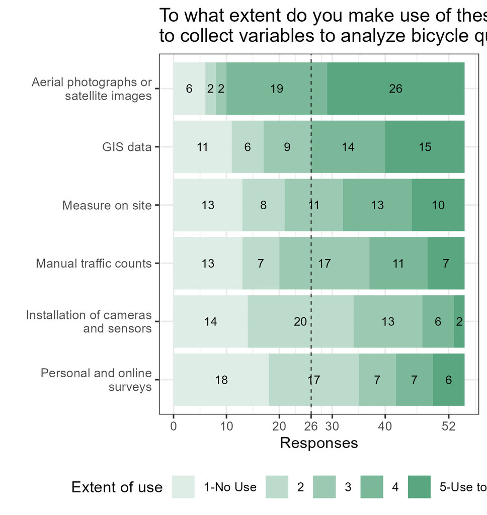

Data sources

## State DOT responses

Which of the following methods do you apply? Check all that apply. State DOT sample size 35

| Methodology | Responses | Percentage |
| --- | --- | --- |
| None | 16 | 45.71 |
| Bicycle level of traffic stress | 14 | 40.00 |
| HCM bicycle level of service | 7 | 20.00 |
| Other | 4 | 12.28 |
| Rural bicycle compatibility index | 0 | 0.00 |

Then, we analyze the use of each method by each state DOT. Hawaii and Alaska used none of the methodologies.

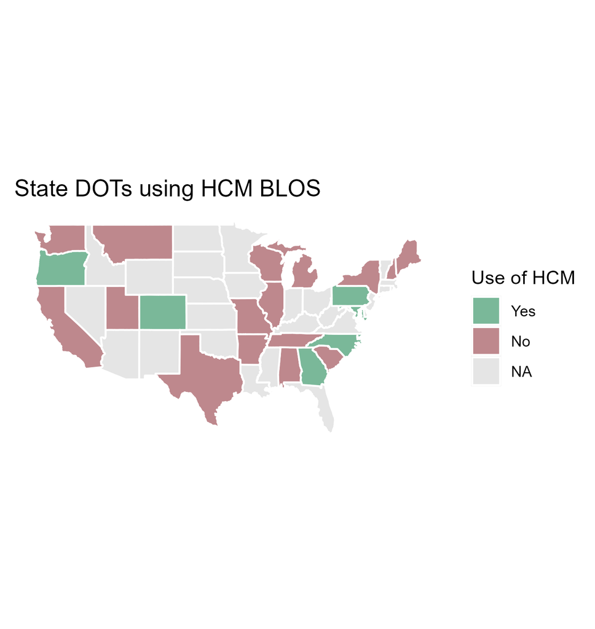

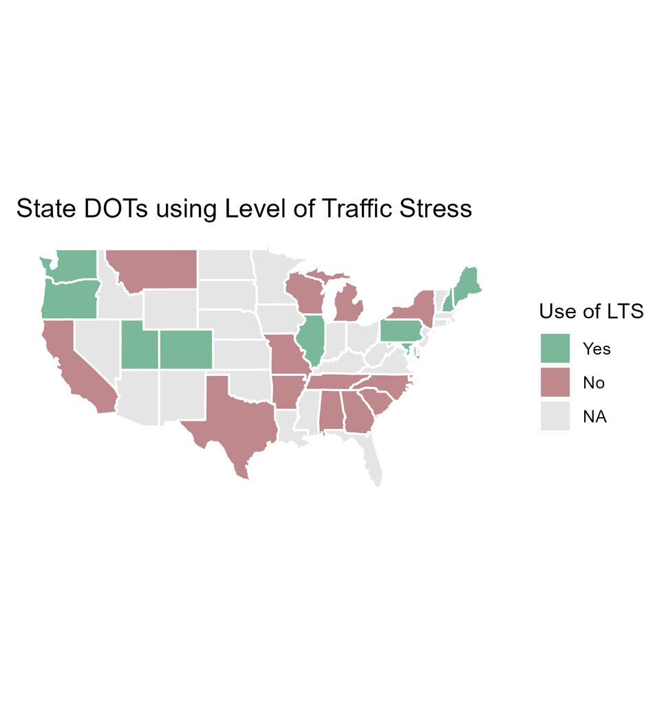

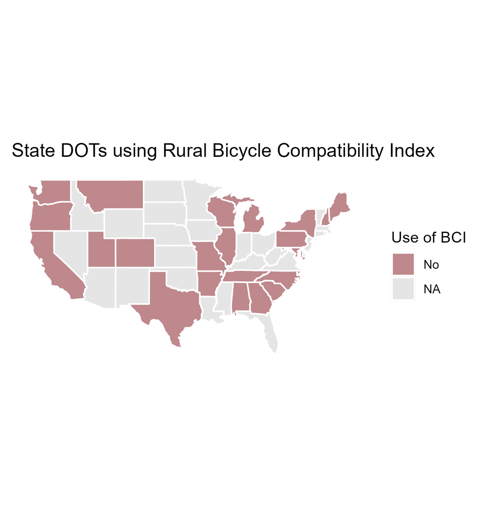

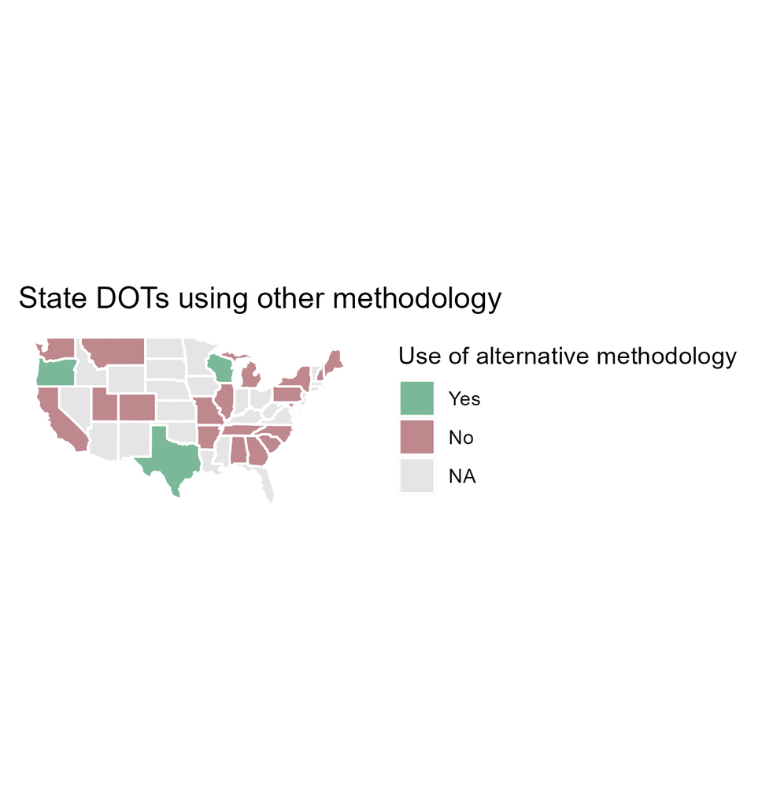

Concerns for state DOTs are similar to other respondents, being data availability and insufficient staff the most predominant.

What are your main concerns regarding bicycle indicators? Check all that apply

| Concerns | Responses | Percentage |
| --- | --- | --- |
| We do not have access to all the input data | 17 | 48.57 |
| It is challenging to have sufficient staff to estimate them | 17 | 48.57 |
| Other | 9 | 25.71 |
| The input data are too expensive to collect | 8 | 22.86 |
| The indicators are not relevant to our local condition | 5 | 14.29 |
| The indicators are not capable to assess our needs | 4 | 11.43 |
| The methodology is too complex | 3 | 8.57 |
| None | 2 | 5.71 |

Data sources of state DOTs are predominantly aerial photographs, with only 5 respondents not using them.

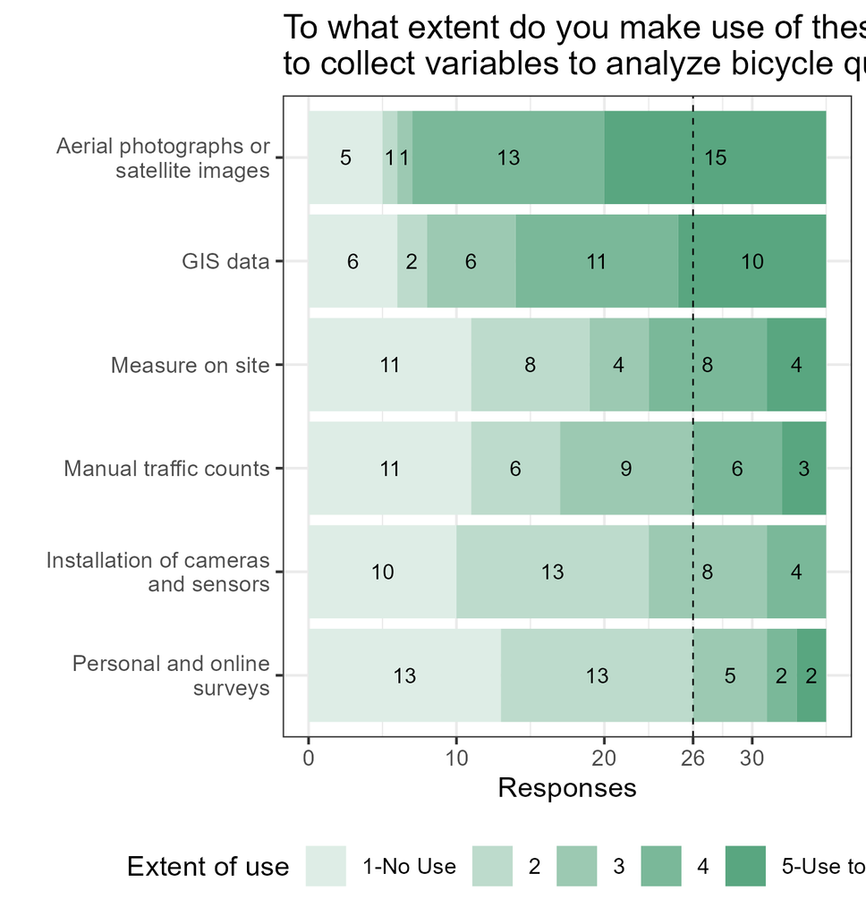

Data sources state DOTs

# Quality of service for rural cyclists

The main section of the survey is devoted to assess the influence on perceived quality of service of certain variables.

Firstly, respondents were asked to evaluate how sensitive are rural cyclist perceptions of quality of service to the individual variables. A 5-point Likert scale ranging from “1 - No effect” to “5 - Very sensitive” was used to categorize the responses. Responses for both shared lanes and bicycle lanes were collected. They were classified in five main categories: design elements, traffic characteristics, traffic control elements, land use, and environmental conditions.

In order to better visualize the results, variables were arranged in descending order by median and mean value. It was checked that the order of how individual elements were presented did not influenced the results (e.g. first element had always the highest scores, or elements are ordered by presentation order). Afterwards, a final comparison across all individual variables is performed.

Secondly, respondents were asked to rank eight group of variables based on their relative importance to assess the quality of service for rural cyclists. Similarly, groups were ordered by median and mean value. Moreover, a comparison was included depending on which methods are applied and bicyclist experience.

## Analysis of individual variables

### Design elements

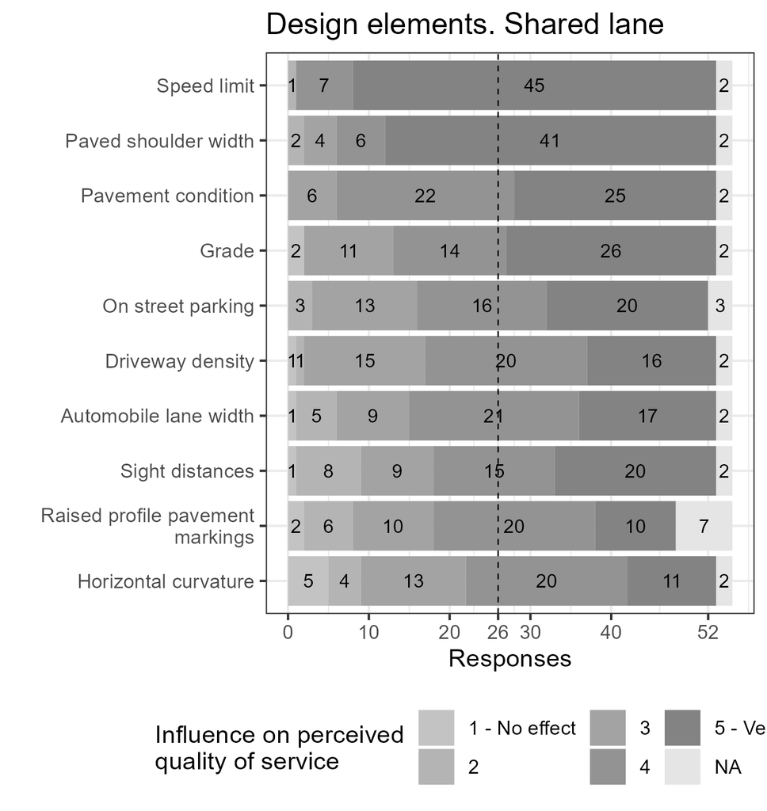

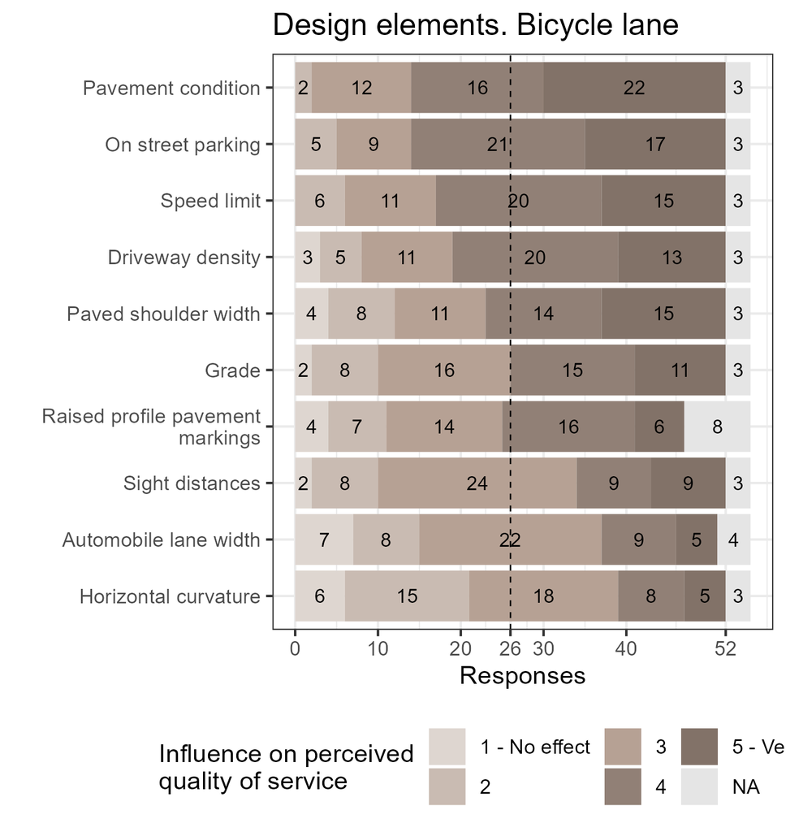

### Traffic characteristics

As for traffic characteristics, we observe two groups of responses on both shared and bicycle lanes. The first group consist of “4” and “5 - very sensitive” traffic characteristics: lateral clearance, automobile average speed, speed differential and directional automobile volume. These traffic characteristics can be categorized as “clearance-related” and “speed-related”. In the case of shared lanes, the percentage of “5 – very sensitive” response is greater than for bicycle lanes.

Other traffic characteristics presented more dispersed responses and the relative order differed in shared lanes and bicycle lanes. For example, bicycle volume had higher significance for bicycle lanes than for shared lanes. Not surprisingly, the influence of opposing traffic volume decreased on bicycle lanes, compared to shared lanes.

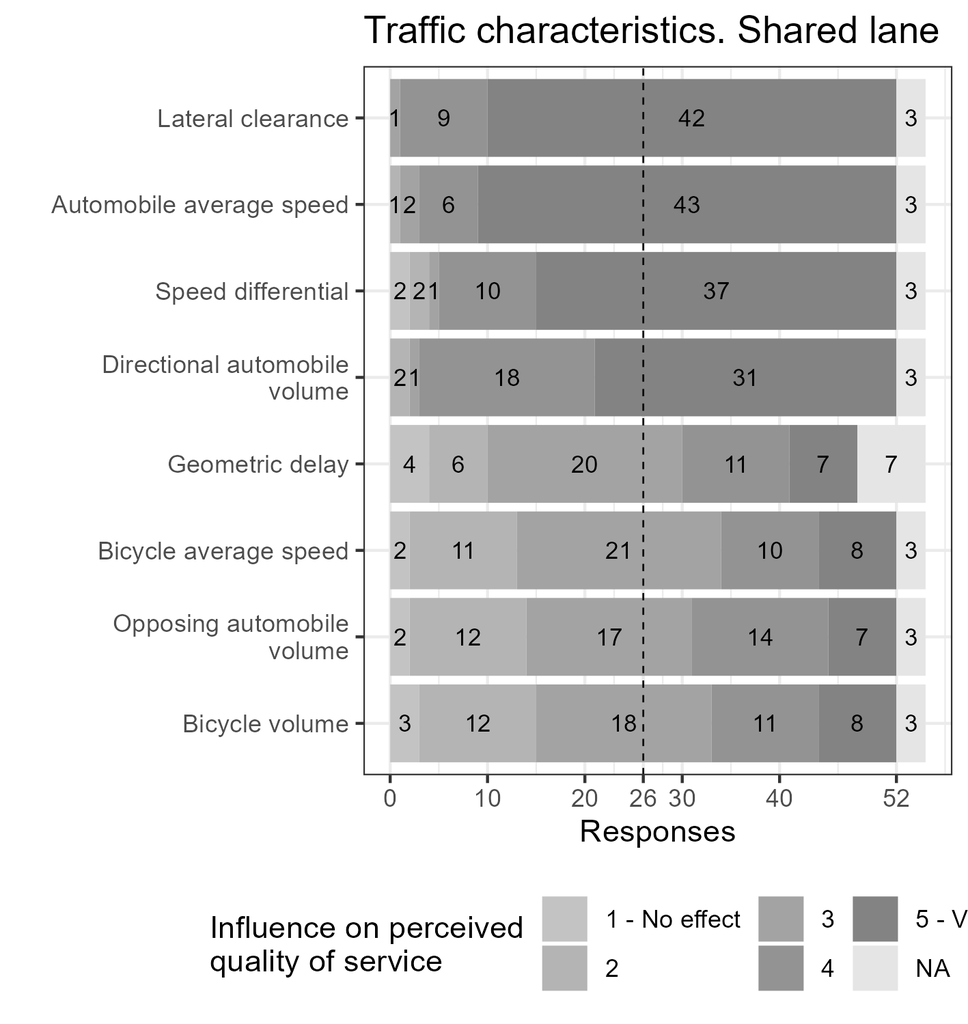

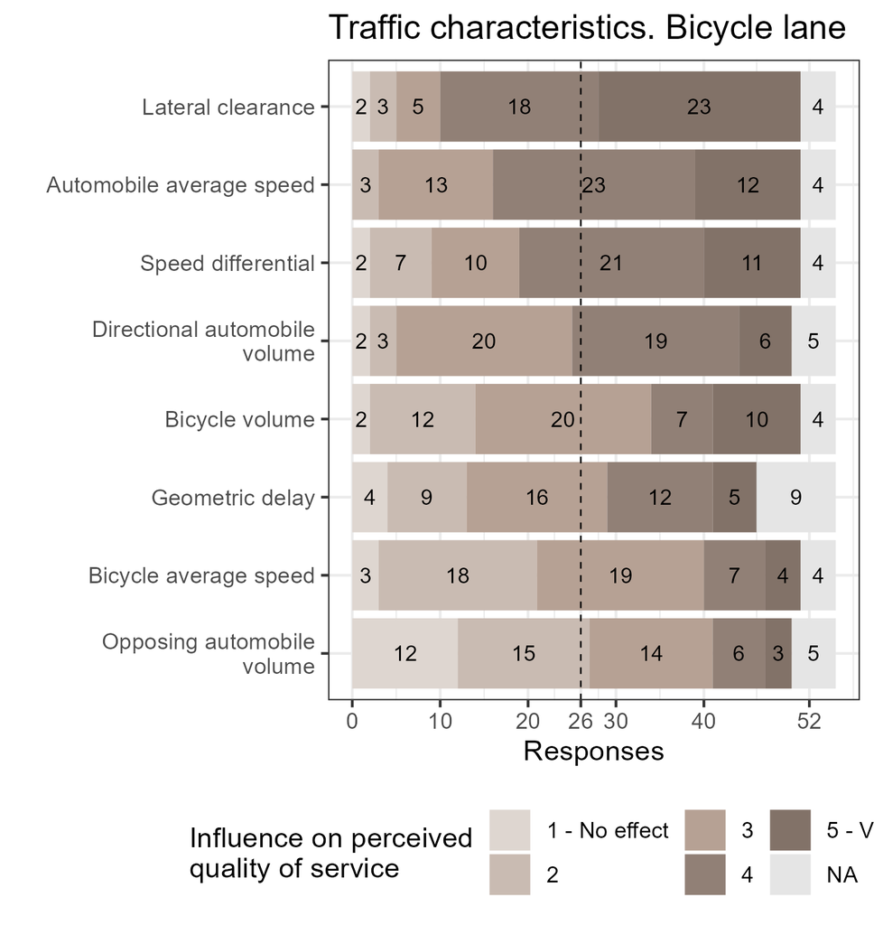

### Traffic control elements

Signalized intersections, roundabouts and stop-controlled intersection presented very similar results for both shared lanes and bicycle lanes. Their influence on perceived quality of service was between “3” and “5-very sensitive”, with the majority of responses equal to “4”. Signalized intersections presented higher scores than roundabouts and stop-controlled intersections, although the differences were marginal.

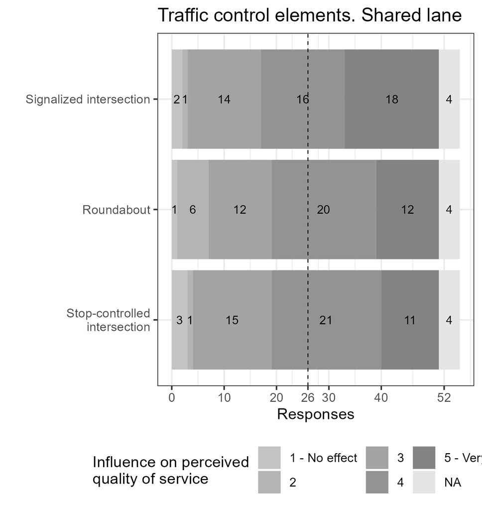

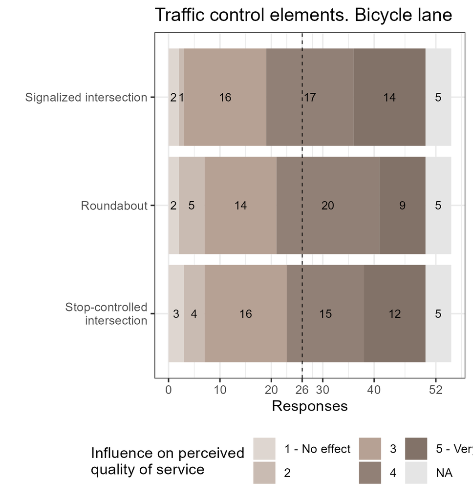

### Land use

The relative order of adjacent land uses was the same for shared and bicycle lanes. The most important land use was commercial areas, mainly because it is expected a higher interaction between cyclists and other users, such as pedestrians or turning automobiles. In the case of shared lanes, 40 respondents indicated “4” or “5 – very sensitive”, compared to 32 respondents on bicycle lanes. The next land use was industrial and military areas, on where it is also expected some interaction with heavy vehicles. In this case, the number of responses equal or greater than “4” was between 26 and 34.

The land uses with the lowest influence on perceived quality of service were federal/state parks and agricultural zones. Most of their responses were equal to “2” and “3”.

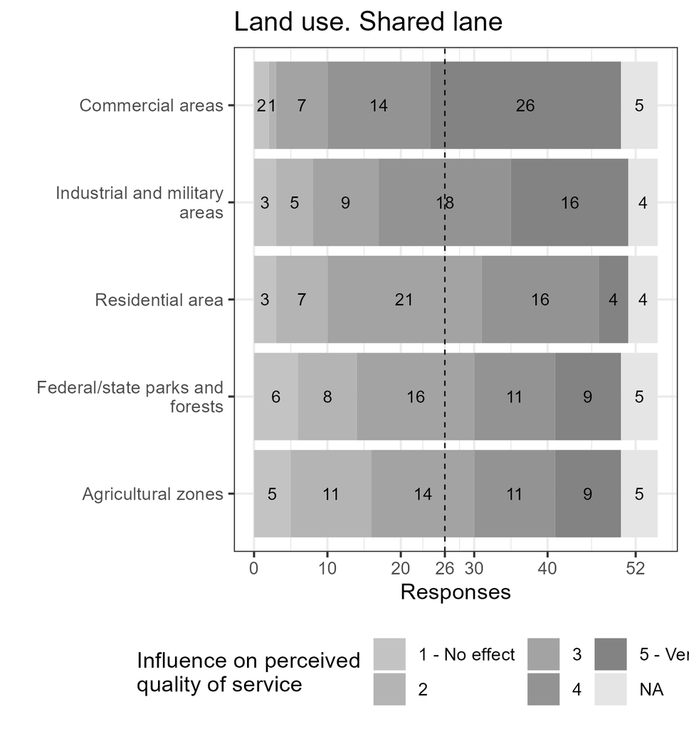

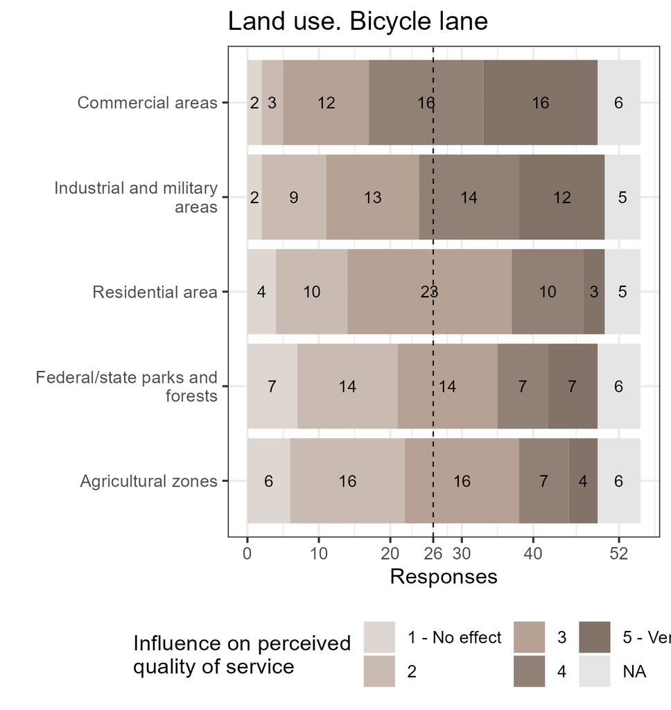

### Environmental conditions

The last group of elements were environmental conditions. Most of responses were “5 – very sensitive” for snow, fog, rainfall, light condition and wind. This relative order of environmental conditions was the same for both shared and bicycle lanes. Similar as previous groups, the percentage of “5 – very sensitive” responses was higher on shared lanes. Temperature had more dispersed responses, with the majority of responses equal to “3”.

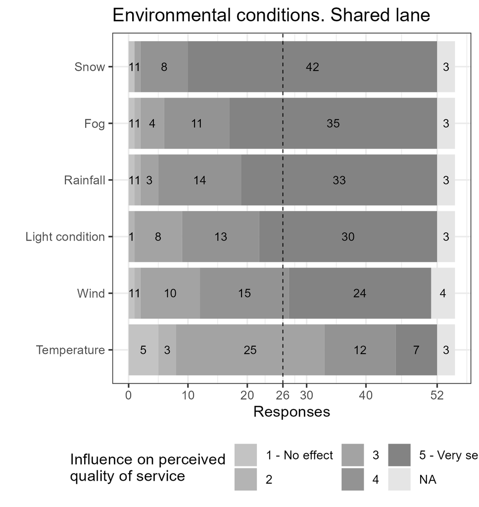

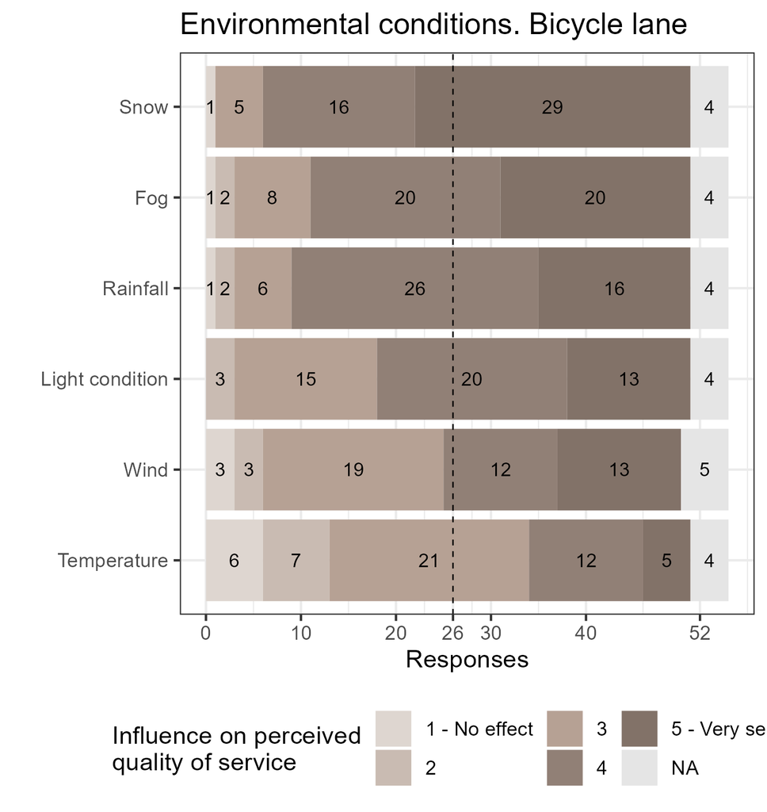

## Comparison across variables

We can observe that the order and median value slightly differ between shared and bicycle lanes. However, there are commonalities between shared and bicycle lanes. The most important elements for both facilities can be arranged as follows:

- “Speed-related”: speed limit, automobile average speed, speed differential
- “Clearance-related”: lateral clearance, paved shoulder width
- “Environmental-related”: fog, light condition, wind
- “Hindrance-related”: directional automobile volumes, commercial areas, on-street parking, driveway density
- “Actual pavement condition”: pavement condition, snow, rainfall
- “Delay-related”: intersection, roundabout

Overall, shared lanes presented higher median and mean values. The relative importance of speed-related and clearance-related elements was higher for shared lanes than for bicycle lanes. On bicycle lanes, environmental and activity volume-related elements played a more important role, as separated bicycle lanes reduce the impact of automobiles on perceived quality of service. In both cases, pavement condition was highly important. The HCM analysis procedure for bicycle mode accounts for most of them, except for environmental factors.

| Shared lane Variables | Shared lane Median | Shared lane Mean |
| --- | --- | --- |
| Speed limit | 5 | 4.81 |
| Lateral clearance | 5 | 4.79 |
| Automobile average speed | 5 | 4.75 |
| Snow | 5 | 4.73 |
| Paved shoulder width | 5 | 4.62 |
| Directional automobile volume | 5 | 4.50 |
| Speed differential | 5 | 4.50 |
| Fog | 5 | 4.50 |
| Rainfall | 5 | 4.48 |
| Light condition | 5 | 4.38 |
| Commercial areas | 5 | 4.22 |
| Pavement condition | 4 | 4.36 |
| Wind | 4 | 4.18 |
| Grade | 4 | 4.17 |
| On street parking | 4 | 4.02 |
| Driveway density | 4 | 3.92 |
| Signalized intersection | 4 | 3.92 |
| Automobile lane width | 4 | 3.91 |
| Sight distances | 4 | 3.85 |
| Industrial and military areas | 4 | 3.76 |
| Stop-controlled intersection | 4 | 3.71 |
| Roundabout | 4 | 3.71 |
| Raised profile pavement markings | 4 | 3.62 |
| Horizontal curvature | 4 | 3.53 |
| Temperature | 3 | 3.25 |
| Opposing automobile volume | 3 | 3.23 |
| Geometric delay | 3 | 3.23 |
| Residential area | 3 | 3.22 |
| Bicycle average speed | 3 | 3.21 |
| Federal/state parks and forests | 3 | 3.18 |
| Bicycle volume | 3 | 3.17 |
| Agricultural zones | 3 | 3.16 |

Note:  
Descending order by median and mean

| Bicycle lane Variables | Bicycle lane Median | Bicycle lane Mean |
| --- | --- | --- |
| Snow | 5.0 | 4.41 |
| Pavement condition | 4.0 | 4.12 |
| Lateral clearance | 4.0 | 4.12 |
| Fog | 4.0 | 4.10 |
| Rainfall | 4.0 | 4.06 |
| On street parking | 4.0 | 3.96 |
| Automobile average speed | 4.0 | 3.86 |
| Speed limit | 4.0 | 3.85 |
| Commercial areas | 4.0 | 3.84 |
| Light condition | 4.0 | 3.84 |
| Signalized intersection | 4.0 | 3.80 |
| Driveway density | 4.0 | 3.67 |
| Speed differential | 4.0 | 3.63 |
| Stop-controlled intersection | 4.0 | 3.58 |
| Roundabout | 4.0 | 3.58 |
| Paved shoulder width | 4.0 | 3.54 |
| Industrial and military areas | 4.0 | 3.50 |
| Wind | 3.5 | 3.58 |
| Grade | 3.5 | 3.48 |
| Directional automobile volume | 3.5 | 3.48 |
| Sight distances | 3.0 | 3.29 |
| Raised profile pavement markings | 3.0 | 3.28 |
| Bicycle volume | 3.0 | 3.22 |
| Geometric delay | 3.0 | 3.11 |
| Temperature | 3.0 | 3.06 |
| Residential area | 3.0 | 2.96 |
| Automobile lane width | 3.0 | 2.94 |
| Federal/state parks and forests | 3.0 | 2.86 |
| Horizontal curvature | 3.0 | 2.83 |
| Bicycle average speed | 3.0 | 2.82 |
| Agricultural zones | 3.0 | 2.73 |
| Opposing automobile volume | 2.0 | 2.46 |

Note:  
Descending order by median and mean

## Rank of variables

In the last question of this section, respondents were asked to rank eight group of variables based on their relative importance to assess the quality of service for rural cyclists.

Firstly, we analyzed the frequency of each response. To facilitate the visualization, we merged the responses in four ranks: “1st – most important or 2nd”, “3rd or 4th”, 5th or 6th” and “7th or 8th – least important”, and ordered the elements based on their median rank.

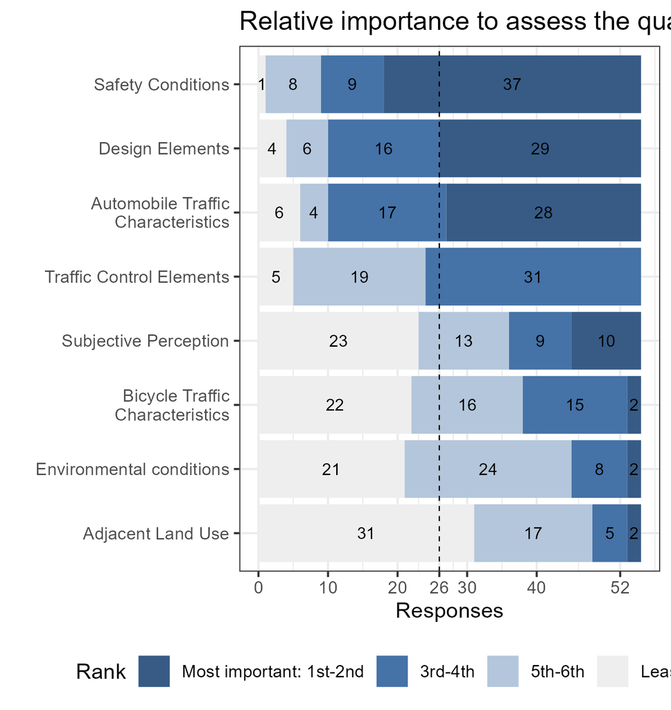

Please rank the following group of variables based on their relative importance to assess the quality of service for rural cyclists. Rank 1: most important, Rank 8: least important

| Rank | Variables | Median | Mean | IQR |
| --- | --- | --- | --- | --- |
| 1st | Safety Conditions | 2 | 2.33 | 2 |
| 2nd | Design Elements | 2 | 2.93 | 2 |
| 3rd | Automobile Traffic Characteristics | 2 | 3.11 | 2 |
| 4th | Traffic Control Elements | 4 | 4.55 | 3 |
| 5th | Bicycle Traffic Characteristics | 5 | 5.73 | 4 |
| 6th | Subjective Perception | 6 | 5.38 | 3 |
| 7th | Environmental conditions | 6 | 5.80 | 2 |
| 8th | Adjacent Land Use | 7 | 6.38 | 3 |

Afterwards, we analyze if the respondent cycling experience had an influence on how variables were ranked. We used three categories of cycling experience:

- Frequent rural cyclist: cycles for commute and/or leisure on rural highways at least once per week.
- Frequent cyclist: cycles for commute and/or leisure in urban areas and/or rural segregated bicycle ways at least once per week.
- Occasional cyclist or no cyclist: cyclists that cannot be classified as frequent rural or frequent cyclist.

The results indicated slight differences depending on cycling experience. Respondents agreed on the three highest ranked variables: safety conditions, design elements and automobile traffic characteristics. However, frequent rural and frequent cyclists valued more automobile traffic characteristics than design elements, compared to occasional or no cyclists.

The three groups also agreed on the 4th ranked group: traffic control elements; and which were the four lowest ranked variables: subjective perception, bicycle traffic characteristics, environmental conditions and adjacent land use. We could observe that frequent rural cyclists provided a lower relative importance to environmental conditions, compared to other cyclists, and that they valued more subjective perception. On the other hand, occasional or no cyclists valued more bicycle traffic characteristics, which had a lower ranking for frequent rural and frequent cyclists.

Ranked variables by cycling experience

| Rank | All responses | Responses by cycling experience Frequent rural cyclist | Responses by cycling experience Frequent cyclist | Responses by cycling experience Occasional or no cyclist |
| --- | --- | --- | --- | --- |
| 1st | Safety Conditions (m=2) | Safety Conditions (m=2) | Safety Conditions (m=2) | Safety Conditions (m=1) |
| 2nd | Design Elements (m=2) | Automobile Traffic Characteristics (m=2.5) | Automobile Traffic Characteristics (m=2) | Design Elements (m=2) |
| 3rd | Automobile Traffic Characteristics (m=2) | Design Elements (m=3) | Design Elements (m=2) | Automobile Traffic Characteristics (m=3) |
| 4th | Traffic Control Elements (m=4) | Traffic Control Elements (m=4.5) | Traffic Control Elements (m=4) | Traffic Control Elements (m=4) |
| 5th | Bicycle Traffic Characteristics (m=5) | Subjective Perception (m=5) | Environmental conditions (m=5.5) | Bicycle Traffic Characteristics (m=5) |
| 6th | Subjective Perception (m=6) | Bicycle Traffic Characteristics (m=5.5) | Bicycle Traffic Characteristics (m=6) | Environmental conditions (m=6) |
| 7th | Environmental conditions (m=6) | Environmental conditions (m=6) | Subjective Perception (m=6.5) | Subjective Perception (m=7) |
| 8th | Adjacent Land Use (m=7) | Adjacent Land Use (m=6.5) | Adjacent Land Use (m=7) | Adjacent Land Use (m=7) |

Note:  
m: Median rank

A similar analysis was carried out depending on the applied methodology. There were minor differences. Significantly, users of the level of traffic stress ranked higher design elements than safety conditions.

Ranked variables by applied methodology

| Rank | All responses | Responses by used method Highway Capacity Manual | Responses by used method Level of Traffic Stress | Responses by used method None |
| --- | --- | --- | --- | --- |
| 1st | Safety Conditions (m=2) | Safety Conditions (m=1.5) | Design Elements (m=2) | Safety Conditions (m=1) |
| 2nd | Design Elements (m=2) | Design Elements (m=2) | Safety Conditions (m=2) | Automobile Traffic Characteristics (m=2) |
| 3rd | Automobile Traffic Characteristics (m=2) | Automobile Traffic Characteristics (m=3) | Automobile Traffic Characteristics (m=2) | Design Elements (m=3) |
| 4th | Traffic Control Elements (m=4) | Traffic Control Elements (m=4.5) | Traffic Control Elements (m=4) | Traffic Control Elements (m=4) |
| 5th | Bicycle Traffic Characteristics (m=5) | Subjective Perception (m=5) | Subjective Perception (m=6) | Bicycle Traffic Characteristics (m=6) |
| 6th | Subjective Perception (m=6) | Bicycle Traffic Characteristics (m=5.5) | Environmental conditions (m=6) | Environmental conditions (m=6) |
| 7th | Environmental conditions (m=6) | Environmental conditions (m=6) | Bicycle Traffic Characteristics (m=6) | Adjacent Land Use (m=6) |
| 8th | Adjacent Land Use (m=7) | Adjacent Land Use (m=7.5) | Adjacent Land Use (m=8) | Subjective Perception (m=7) |

Note:  
m: Median rank

# Defining rural cyclists

The third section of the survey included questions to define the rural design user. Specifically, respondents were asked to indicate their agreement to: The following characteristics should be used to define the bicycle design user(s) for rural highways.

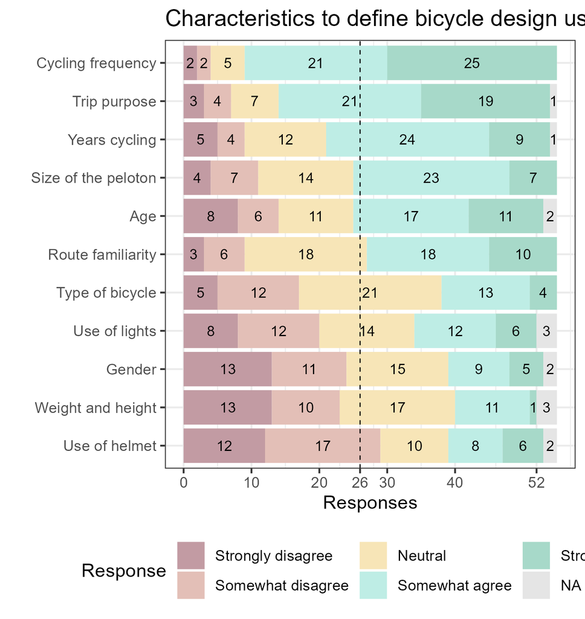

Similar conclusions can be derived from the analysis of median and IQR. Most respondents indicated agreement with the idea that cycling frequency, trip purpose, years cycling, size of the peloton, age and route familiarity could be used to define bicycle design users for rural highways (median = 1, IQR <= 2). Neutral opinions were found for type of bicycle, use of lights, gender and weight/height, although there was a high dispersion on the responses (median = 0, IQR >= 2). Most respondents indicated disagreement with the use of helmet as one characteristic to define bicycle design users (median = -1, IQR = 2).

Bicyclist attributes

|  | Variables | Median | Mean |
| --- | --- | --- | --- |
| 1 | Cycling frequency | 1 | 1.18 |
| 2 | Trip purpose | 1 | 0.91 |
| 3 | Years cycling | 1 | 0.52 |
| 4 | Route familiarity | 1 | 0.47 |
| 5 | Size of the peloton | 1 | 0.40 |
| 6 | Age | 1 | 0.32 |
| 7 | Type of bicycle | 0 | -0.02 |
| 8 | Use of lights | 0 | -0.08 |
| 9 | Gender | 0 | -0.34 |
| 10 | Weight and height | 0 | -0.44 |
| 11 | Use of helmet | -1 | -0.40 |

Ordered variables by cycling experience

|  | All responses | Responses by cycling experience Frequent rural cyclist | Responses by cycling experience Frequent cyclist | Responses by cycling experience Occasional or no cyclist |
| --- | --- | --- | --- | --- |
| 1 | Cycling frequency (m=1) | Cycling frequency (m=2) | Cycling frequency (m=1) | Cycling frequency (m=2) |
| 2 | Trip purpose (m=1) | Trip purpose (m=2) | Trip purpose (m=1) | Trip purpose (m=1) |
| 3 | Years cycling (m=1) | Years cycling (m=1) | Size of the peloton (m=1) | Years cycling (m=1) |
| 4 | Route familiarity (m=1) | Route familiarity (m=0.5) | Age (m=1) | Route familiarity (m=1) |
| 5 | Size of the peloton (m=1) | Age (m=0.5) | Route familiarity (m=0.5) | Size of the peloton (m=1) |
| 6 | Age (m=1) | Size of the peloton (m=0.5) | Years cycling (m=0) | Age (m=0.5) |
| 7 | Type of bicycle (m=0) | Type of bicycle (m=0) | Type of bicycle (m=0) | Use of lights (m=0) |
| 8 | Use of lights (m=0) | Use of lights (m=0) | Use of lights (m=0) | Use of helmet (m=0) |
| 9 | Gender (m=0) | Gender (m=-0.5) | Weight and height (m=0) | Type of bicycle (m=0) |
| 10 | Weight and height (m=0) | Use of helmet (m=-1) | Use of helmet (m=-0.5) | Gender (m=0) |
| 11 | Use of helmet (m=-1) | Weight and height (m=-1) | Gender (m=-1) | Weight and height (m=0) |

General: m: median  
Interpretation: <sup>1</sup> General agreement with the attribute (median > 0); <sup>2</sup> Neutral position towards the attribute (median = 0); <sup>3</sup> General disagreement with the attribute (median < 0)

The analysis by applied methodology reveals similar results. There was a general agreement on which attributes should be considered to define design users by all respondents. Interestingly, HCM users and LTS users had neutral response towards route familiarity, and strong agreement with cycling frequency. HCM users had more disagreement on more attributes, such as the type of bicycle, use of helmet, gender and physical characteristics.

Some respondents also provided further comments on a free-text box. The comments were analyzed and classified by which attributes shall be considered when defining the design user. Not surprisingly, experience was mentioned by more respondents, as well as age.

Comments to bicyclist attributes. Attributes that should be considered

| Attribute | Count |
| --- | --- |
| Experience | 7 |
| Inclusion of all users | 6 |
| Age | 5 |
| Gender | 4 |
| Ability to bike | 2 |
| Data should be easily obtained | 2 |
| Physical characteristics | 2 |
| Amount of time riding | 1 |
| Education programs to change behavior (use of lights, helmet) | 1 |
| Familiarity with the route | 1 |
| Group | 1 |
| Height | 1 |
| Important for design | 1 |
| Infrastructure | 1 |
| Infrastructure | 1 |
| Physical fitness | 1 |
| Safety | 1 |
| Type of Bicycle | 1 |

Some comments also indicated which attributes were not significant to the respondents. 9 out of 51 respondents indicated that there is no need for a design user and that it should be designed for all users regardless their age, abilities or experience. Other attributes that were explicitly mentioned to not be considered were physical characteristics, use of helmet or gender.

Comments to bicyclist attributes. Attributes that should not be considered?

| Attribute | Count |
| --- | --- |
| Design user | 9 |
| Physical characteristics | 5 |
| Helmet | 4 |
| Gender | 2 |
| Group | 2 |
| Trip purpose | 1 |
| Type of bike | 1 |
| Years of cycling | 1 |

# Conclusions

Conclusions of the study are limited to the designed questionnaire and to the collected responses. The extrapolation of these results to specific geographical areas should be undertaken with caution, since sample size was limited. Based on these conclusions, the recommendations of the study are:

- Bicycle level of service scores for shared lanes and bicycle lanes should be distinct; as their sensitivity to variables differ. The results of this survey should be further validated with an effort to collect user perception to the groups of variables by facility type.
- Corridor analyses should be considered to evaluate the quality of service for cyclists along rural highways. A future methodology should be able to accommodate different facility types and context classifications seamlessly.
- This research points to the need for future discussions on the role of bicycle user segmentation for operational analyses. In the case that the Highway Capacity Manual analysis procedure aligns with the current LTS-based design criteria, different LOS thresholds should be considered for different bicycle users. The most important characteristics have been identified, but specific criteria and thresholds still need to be defined.

For future research, the team is designing a survey targeted to bicycle riders of rural highways to validate the conclusions from the transportation planner/engineer practitioner survey. Based on the results of both surveys, recommendations on potential revisions/improvements to the HCM bicycle LOS methodology and user segmentation will be developed.

# Appendix

## Shared lane. Statistics summaries

How sensitive are rural cyclist perceptions of quality of service to the following variables? Consider the following scale: 1 - No effect to 5 - Very sensitive (Variables in descending order)

| Variables | Median | Mean | Standard deviation |
| --- | --- | --- | --- |
| Speed limit | 5 | 4.81 | 0.52 |
| Lateral clearance | 5 | 4.79 | 0.46 |
| Automobile average speed | 5 | 4.75 | 0.62 |
| Snow | 5 | 4.73 | 0.69 |
| Paved shoulder width | 5 | 4.62 | 0.79 |
| Directional automobile volume | 5 | 4.50 | 0.73 |
| Speed differential | 5 | 4.50 | 1.00 |
| Fog | 5 | 4.50 | 0.87 |
| Rainfall | 5 | 4.48 | 0.85 |
| Light condition | 5 | 4.38 | 0.82 |
| Commercial areas | 5 | 4.22 | 1.04 |
| Pavement condition | 4 | 4.36 | 0.68 |
| Wind | 4 | 4.18 | 0.95 |
| Grade | 4 | 4.17 | 1.01 |
| On street parking | 4 | 4.02 | 0.94 |
| Driveway density | 4 | 3.92 | 0.92 |
| Signalized intersection | 4 | 3.92 | 1.04 |
| Automobile lane width | 4 | 3.91 | 1.02 |
| Sight distances | 4 | 3.85 | 1.15 |
| Industrial and military areas | 4 | 3.76 | 1.18 |
| Stop-controlled intersection | 4 | 3.71 | 1.03 |
| Roundabout | 4 | 3.71 | 1.03 |
| Raised profile pavement markings | 4 | 3.62 | 1.08 |
| Horizontal curvature | 4 | 3.53 | 1.19 |
| Temperature | 3 | 3.25 | 1.08 |
| Opposing automobile volume | 3 | 3.23 | 1.08 |
| Geometric delay | 3 | 3.23 | 1.12 |
| Residential area | 3 | 3.22 | 0.99 |
| Bicycle average speed | 3 | 3.21 | 1.07 |
| Federal/state parks and forests | 3 | 3.18 | 1.26 |
| Bicycle volume | 3 | 3.17 | 1.13 |
| Agricultural zones | 3 | 3.16 | 1.25 |

## Bicycle lane. Statistics summaries

How sensitive are rural cyclist perceptions of quality of service to the following variables? Consider the following scale: 1 - No effect to 5 - Very sensitive (Variables in descending order)

| Variables | Median | Mean | Standard deviation |
| --- | --- | --- | --- |
| Snow | 5.0 | 4.41 | 0.83 |
| Pavement condition | 4.0 | 4.12 | 0.90 |
| Lateral clearance | 4.0 | 4.12 | 1.07 |
| Fog | 4.0 | 4.10 | 0.94 |
| Rainfall | 4.0 | 4.06 | 0.88 |
| On street parking | 4.0 | 3.96 | 0.95 |
| Automobile average speed | 4.0 | 3.86 | 0.85 |
| Speed limit | 4.0 | 3.85 | 0.98 |
| Commercial areas | 4.0 | 3.84 | 1.09 |
| Light condition | 4.0 | 3.84 | 0.88 |
| Signalized intersection | 4.0 | 3.80 | 1.01 |
| Driveway density | 4.0 | 3.67 | 1.13 |
| Speed differential | 4.0 | 3.63 | 1.09 |
| Stop-controlled intersection | 4.0 | 3.58 | 1.13 |
| Roundabout | 4.0 | 3.58 | 1.03 |
| Paved shoulder width | 4.0 | 3.54 | 1.28 |
| Industrial and military areas | 4.0 | 3.50 | 1.16 |
| Wind | 3.5 | 3.58 | 1.13 |
| Grade | 3.5 | 3.48 | 1.11 |
| Directional automobile volume | 3.5 | 3.48 | 0.93 |
| Sight distances | 3.0 | 3.29 | 1.05 |
| Raised profile pavement markings | 3.0 | 3.28 | 1.14 |
| Bicycle volume | 3.0 | 3.22 | 1.14 |
| Geometric delay | 3.0 | 3.11 | 1.12 |
| Temperature | 3.0 | 3.06 | 1.12 |
| Residential area | 3.0 | 2.96 | 0.99 |
| Automobile lane width | 3.0 | 2.94 | 1.14 |
| Federal/state parks and forests | 3.0 | 2.86 | 1.26 |
| Horizontal curvature | 3.0 | 2.83 | 1.13 |
| Bicycle average speed | 3.0 | 2.82 | 1.01 |
| Agricultural zones | 3.0 | 2.73 | 1.11 |
| Opposing automobile volume | 2.0 | 2.46 | 1.16 |

## Ranked variables. Statistics summaries

Please rank the following group of variables based on their relative importance to assess the quality of service for rural cyclists. Rank 1: most important, Rank 8: least important

| Variables | Median | Mean | Standard deviation |
| --- | --- | --- | --- |
| Safety Conditions | 2 | 2.33 | 1.68 |
| Design Elements | 2 | 2.93 | 1.85 |
| Automobile Traffic Characteristics | 2 | 3.11 | 2.06 |
| Traffic Control Elements | 4 | 4.55 | 1.41 |
| Bicycle Traffic Characteristics | 5 | 5.73 | 1.87 |
| Subjective Perception | 6 | 5.38 | 2.31 |
| Environmental conditions | 6 | 5.80 | 1.65 |
| Adjacent Land Use | 7 | 6.38 | 1.69 |

## Bicyclist attributes. Statistics summaries

The following characteristics should be used to define the bicycle design user(s) for rural highways? Consider the following scale: -2: Strongly disagree, 0: Neutral, 2: Strongly agree

| Variables | Median | Mean | Standard deviation |
| --- | --- | --- | --- |
| Cycling frequency | 1 | 1.18 | 1.00 |
| Trip purpose | 1 | 0.91 | 1.14 |
| Years cycling | 1 | 0.52 | 1.14 |
| Route familiarity | 1 | 0.47 | 1.09 |
| Size of the peloton | 1 | 0.40 | 1.10 |
| Age | 1 | 0.32 | 1.34 |
| Type of bicycle | 0 | -0.02 | 1.06 |
| Use of lights | 0 | -0.08 | 1.25 |
| Gender | 0 | -0.34 | 1.29 |
| Weight and height | 0 | -0.44 | 1.14 |
| Use of helmet | -1 | -0.40 | 1.31 |